# Data Programming

Homework 3, 2024

**EN**

**General guidelines for all homework assignments (click to expand):**

- If found cheating you will be subject to the punishment as desribed in the rulebook “Rules on examination and assessment of knowledge”, which is available at https://www.famnit.upr.si/sl/o-fakulteti/pravilniki-obrazci
- Use vector operations instead of loops if possible.
- Unless specified otherwise, only packages learned in the lectures/tutorials may be used (default: base, datasets, graphics, drDevices, methods, stats, utils; custom: tidyverse, lubridate, readxl, writexl, …).

Some key differences between Quarto and R scripts:

- Importing, exporting is relative to the location of the qmd file and not the project directory.
- Do not try to display enourmous data frames as rendering will take a long time.
- Load the custom packages you are using (or use prefixes such as base::_).
- Careful when redering: error: true allows compilation regardless of critical errors.

Submit a **.html** file created using Quarto via e-classroom. Display all code (packages, input) and output.

### 1

Draw a line chart with ggplot of temperature over time side by side for the 2 the build-in data frames **beaver1** and **beaver2**. Add a Title and units on the Y-axis for temperature.

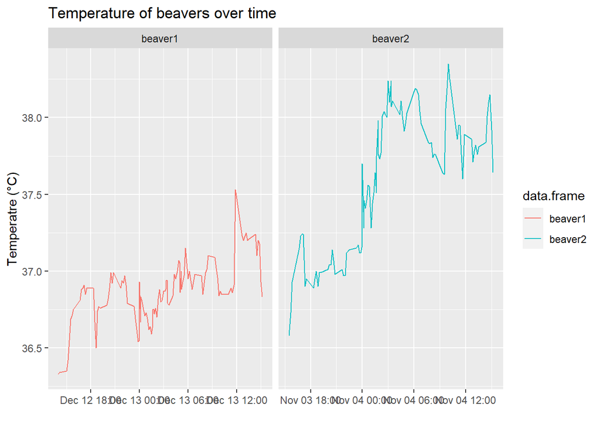

### 2

You are given the worth of 1 EUR in some currencies:

```r
c(EUR=1,datasets::euro)
```

```
        EUR         ATS         BEF         DEM         ESP         FIM
   1.000000   13.760300   40.339900    1.955830  166.386000    5.945730
        FRF         IEP         ITL         LUF         NLG         PTE
   6.559570    0.787564 1936.270000   40.339900    2.203710  200.482000
```

Write a function of two parameters

1. a named numeric vector, with values representing the amount of currency in the corresponding name owned,
2. (optional) a currency to convert to.

The function returns the total amount from 1. as the currency specified in 2. If currency in 2. is not specified then return the value in EUR. If a currency from 1. does not exists, then that part of the vector contributes 0 to the output. If the currency from 2. does not exist then return 0.

Run your code on the following examples:

```r
convert.all(c(EUR=6.5))
```

```
[1] 6.5
```

```r
convert.all(c(EUR=3,ATS=2))
```

```
[1] 3.145346
```

```r
convert.all(c(EUR=3,EUR=2))
```

```
[1] 5
```

```r
convert.all(c(EUR=3,DEM=2,SIT=10000))
```

```
[1] 4.022584
```

```r
convert.all(c(EUR=3,DEM=2,SIT=10000),"EUR")
```

```
[1] 4.022584
```

```r
convert.all(c(EUR=3,SIT=10000,DEM=2),"ESP")
```

```
[1] 669.3016
```

```r
convert.all(c(EUR=3,DEM=2,LIRA=100),"SIT")
```

```
[1] 0
```

**SLO**

**Splošna navodila za vse domače naloge (klikni za prikaz):**

- V primeru goljufanja boste kaznovani po pravilniku “Pravilnik o preverjanju in ocenjevanju znanja”, ki je dostopen na https://www.famnit.upr.si/sl/o-fakulteti/pravilniki-obrazci
- Če je mogoče, uporabite vektorske operacije namesto zank.
- Če ni določeno drugače, so dovoljeni samo paketi, iz predavanj/vaj (privzeti: base, datasets, graphics, drDevices, methods, stats, utils; po meri: tidyverse, lubridate, readxl, writexl, …).

Nekaj ključnih razlik med R skripto in Quarto:

- Uvoz, izvoz je relativen na lokacijo qmd datoteke in ne z direktorijem projekta.
- Ne poskušajte prikazati ogromnih podatkovnih okvirov, saj bo pletenje trajalo večno.
- Naložite pakete po meri, ki jih uporabljate (ali pa uporabite predpone, kot je base::_).
- Previdno pri pletenju: error: true omogoča prevajanje ne glede na kritične napake.

Predložite datoteko **.html**, ki je ustvarjena z uporabo Quarta preko e-učilnice. Prikažite vso kodo (pakete, vhod) in izhod.

### 1

Narišite črtni grafikon z ggplot-om temperature tekom časa drug ob drugem za vgrajena podatkovna okvirja **beaver1** in **beaver2**. Dodajte naslov in enote na Y osi za temperaturo.

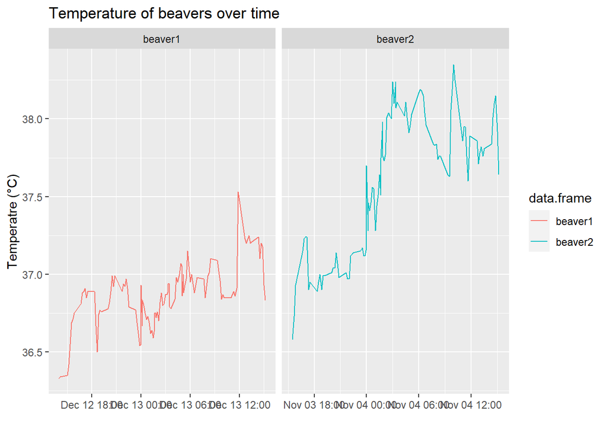

### 2

Dane so vrednosti 1 EUR v nekaterih valutah:

```r
c(EUR=1,datasets::euro)
```

```
        EUR         ATS         BEF         DEM         ESP         FIM
   1.000000   13.760300   40.339900    1.955830  166.386000    5.945730
        FRF         IEP         ITL         LUF         NLG         PTE
   6.559570    0.787564 1936.270000   40.339900    2.203710  200.482000
```

Napišite funkcijo dveh parametrov:

1. imenovani numerični vektor, katerega vrednosti predstavljajo količino valute v ustreznem imenu,
2. (neobvezni parameter) valuta za pretvorbo.

Vrnite skupno količino denarja iz vektorja 1. kot valuto, navedeno v 2. Če valuta ni navedena kot drugi parameter, vrni vrednost v EUR. Če valuta iz 1. ne obstaja, ta del vektorja prinese 0 k končnem rezultatu. Če valuta iz 2. ne obstaja, vrni 0. Zaženite svoj program na naslednjih primerih:

```r
convert.all(c(EUR=6.5))
```

```
[1] 6.5
```

```r
convert.all(c(EUR=3,ATS=2))
```

```
[1] 3.145346
```

```r
convert.all(c(EUR=3,EUR=2))
```

```
[1] 5
```

```r
convert.all(c(EUR=3,DEM=2,SIT=10000))
```

```
[1] 4.022584
```

```r
convert.all(c(EUR=3,DEM=2,SIT=10000),"EUR")
```

```
[1] 4.022584
```

```r
convert.all(c(EUR=3,DEM=2,SIT=10000),"ESP")
```

```
[1] 669.3016
```

```r
convert.all(c(EUR=3,DEM=2,LIRA=100),"SIT")
```

```
[1] 0
```